# EDA MyAnimeList

Kacper Janusz

2026-01-11

## Słowem wstępu

Wśród dostępnych treści rozrywkowych w Polsce, coraz większą popularność zdobywa gatunek [“Anime”](https://pl.wikipedia.org/wiki/Anime).  
Jest to japoński nurt, w którym tworzone są seriale oraz filmy, których główną charakterystyczną cechą jest kreowanie opowieści w kreskówkowym świecie, O bardzo specyficznej stylistyce - nieproporcjonalne wymiary twarzy, wielkie oczy, kolorowe włosy. W Polsce coraz częściej można się zetknąć z napływem tytułów filmowych w kinach, wobec czego uznałem, że jest to doskonała okazja do przebadania społeczności widzów “anime”, oraz poszukanie pewnych wzorców i ciekawych insightów na temat preferencji tej części społeczeństwa.

## Pochodzenie datasetu

Wszystkie dane przedstawiane w poniższym arkuszu pochodzą z portalu [MyAnimeList.net](https://myanimelist.net).  
Jest to jeden z największych portali internetowych, który posiada informacje na temat wszystkich tytułów japońskich seriali rysunkowych, które były, są i będą wydawane. Na portalu kaggle pojawia się co roku zestawienie wszystkich tytułów, od najstarszych istniejących rekordów, aż po te, zgromadzone w roku których dotyczy dataset. Pochodzi ono dokładnie z danych wyżej wspomnianego serwisu. (Na potrzeby bardziej wnikliwych analiz, deweloperzy udostępnili również API). Ja w analizie posłużę się [danymi w 2023](https://www.kaggle.com/datasets/dbdmobile/myanimelist-dataset?select=user-filtered.csv) roku, z prostego powodu - jest to najlepiej przygotowany dataset wśród tych z pozostałych lat. Wybrałem ten, który został przez autora wstępnie przefiltrowany, wobec czego proces schematyzowania zestawu danych powinien przebiec sprawniej.

Zdania podświetlone na żółto są moim zdaniem ciekawymi wątkami które rozwinąłem, jednak pozostają otwarte do dalszej analizy i interpretacji przez czytelnika. Wierzę, że lektura poniższych statystyk da Państwu ogólny pogląd na strukturę społeczności fanów anime i pozwoli być może złapać inspirację, a nawet zachęcić do zagłębienia się w jeden z fantastycznych światów.

## Użyte biblioteki

```r
library(mice)
library(ggplot2)
library(dplyr)
library(stringr)
library(tidyverse)
```

## Wstępna analiza

```r
dataset <- read.csv("anime-filtered.csv")
str(dataset)
```

```
## 'data.frame':    14952 obs. of  25 variables:
##  $ anime_id     : int  1 5 6 7 8 15 16 17 18 19 ...
##  $ Name         : chr  "Cowboy Bebop" "Cowboy Bebop: Tengoku no Tobira" "Trigun" "Witch Hunter Robin" ...
##  $ Score        : num  8.78 8.39 8.24 7.27 6.98 7.95 8.06 7.59 8.15 8.76 ...
##  $ Genres       : chr  "Action, Adventure, Comedy, Drama, Sci-Fi, Space" "Action, Drama, Mystery, Sci-Fi, Space" "Action, Sci-Fi, Adventure, Comedy, Drama, Shounen" "Action, Mystery, Police, Supernatural, Drama, Magic" ...
##  $ English.name : chr  "Cowboy Bebop" "Cowboy Bebop:The Movie" "Trigun" "Witch Hunter Robin" ...
##  $ Japanese.name: chr  "カウボーイビバップ" "カウボーイビバップ 天国の扉" "トライガン" "Witch Hunter ROBIN (ウイッチハンターロビン)" ...
##  $ sypnopsis    : chr  "In the year 2071, humanity has colonized several of the planets and moons of the solar system leaving the now u"| __truncated__ "other day, another bounty—such is the life of the often unlucky crew of the Bebop. However, this routine is int"| __truncated__ "Vash the Stampe…
##  $ Type         : chr  "TV" "Movie" "TV" "TV" ...
##  $ Episodes     : chr  "26" "1" "26" "26" ...
##  $ Aired        : chr  "Apr 3, 1998 to Apr 24, 1999" "Sep 1, 2001" "Apr 1, 1998 to Sep 30, 1998" "Jul 2, 2002 to Dec 24, 2002" ...
##  $ Premiered    : chr  "Spring 1998" "Unknown" "Spring 1998" "Summer 2002" ...
##  $ Producers    : chr  "Bandai Visual" "Sunrise, Bandai Visual" "Victor Entertainment" "TV Tokyo, Bandai Visual, Dentsu, Victor Entertainment" ...
##  $ Licensors    : chr  "Funimation, Bandai Entertainment" "Sony Pictures Entertainment" "Funimation, Geneon Entertainment USA" "Funimation, Bandai Entertainment" ...
##  $ Studios      : chr  "Sunrise" "Bones" "Madhouse" "Sunrise" ...
##  $ Source       : chr  "Original" "Original" "Manga" "Original" ...
##  $ Duration     : chr  "24 min. per ep." "1 hr. 55 min." "24 min. per ep." "25 min. per ep." ...
##  $ Rating       : chr  "R - 17+ (violence & profanity)" "R - 17+ (violence & profanity)" "PG-13 - Teens 13 or older" "PG-13 - Teens 13 or older" ...
##  $ Ranked       : num  28 159 266 2481 3710 ...
##  $ Popularity   : int  39 518 201 1467 4369 1003 687 3612 1233 169 ...
##  $ Members      : int  1251960 273145 558913 94683 13224 148259 214499 20470 117929 614100 ...
##  $ Favorites    : int  61971 1174 12944 587 18 2066 4101 231 979 29436 ...
##  $ Watching     : int  105808 4143 29113 4300 642 13907 11909 817 6082 64648 ...
##  $ Completed    : int  718161 208333 343492 46165 7314 78349 81145 13778 90967 214491 ...
##  $ On.Hold      : int  71513 1935 25465 5121 766 14228 11901 828 3053 47488 ...
##  $ Dropped      : int  26678 770 13925 5378 1108 11573 11026 1168 1356 23008 ...
```

Nasz dataset składa się w sumie z 25 kolumn i 14952 rekordów. Może się to wydawać kolosalna liczba w konteście skali tej analizy, jednak sądzę, że w tym przypadku dobrze jest mieć jak najwięcej datapointów - potencjalne korelacje będą na większej próbie.

```r
summary(dataset)
```

```
##     anime_id         Name               Score          Genres
##  Min.   :    1   Length:14952       Min.   :1.850   Length:14952
##  1st Qu.: 4602   Class :character   1st Qu.:6.080   Class :character
##  Median :16729   Mode  :character   Median :6.510   Mode  :character
##  Mean   :19017                      Mean   :6.512
##  3rd Qu.:33513                      3rd Qu.:7.010
##  Max.   :48492                      Max.   :9.190
##
##  English.name       Japanese.name       sypnopsis             Type
##  Length:14952       Length:14952       Length:14952       Length:14952
##  Class :character   Class :character   Class :character   Class :character
##  Mode  :character   Mode  :character   Mode  :character   Mode  :character
##
##
##
##
##    Episodes            Aired            Premiered          Producers
##  Length:14952       Length:14952       Length:14952       Length:14952
##  Class :character   Class :character   Class :character   Class :character
##  Mode  :character   Mode  :character   Mode  :character   Mode  :character
##
##
##
##
##   Licensors           Studios             Source            Duration
##  Length:14952       Length:14952       Length:14952       Length:14952
##  Class :character   Class :character   Class :character   Class :character
##  Mode  :character   Mode  :character   Mode  :character   Mode  :character
##
##
##
##
##     Rating              Ranked        Popularity       Members
##  Length:14952       Min.   :    1   Min.   :    1   Min.   :    200
##  Class :character   1st Qu.: 3310   1st Qu.: 3732   1st Qu.:    736
##  Mode  :character   Median : 6618   Median : 7466   Median :   3494
##                     Mean   : 6830   Mean   : 7466   Mean   :  40686
##                     3rd Qu.: 9942   3rd Qu.:11194   3rd Qu.:  19193
##                     Max.   :15780   Max.   :17565   Max.   :2589552
##                     NA's   :1721
##    Favorites           Watching        Completed          On.Hold
##  Min.   :     0.0   Min.   :     0   Min.   :      0   Min.   :     0.0
##  1st Qu.:     1.0   1st Qu.:    27   1st Qu.:    246   1st Qu.:    14.0
##  Median :     6.0   Median :   127   Median :   1516   Median :    78.0
##  Mean   :   537.6   Mean   :  2620   Mean   :  25943   Mean   :  1121.3
##  3rd Qu.:    47.0   3rd Qu.:   723   3rd Qu.:   9797   3rd Qu.:   388.2
##  Max.   :183914.0   Max.   :887333   Max.   :2182587   Max.   :187919.0
##
##     Dropped
##  Min.   :     0
##  1st Qu.:    48
##  Median :   102
##  Mean   :  1378
##  3rd Qu.:   377
##  Max.   :174710
##
```

### Opis kolumn

Mamy 25 kolumn, w których mamy dane ilościowe, jakościowe, oraz widać od razu, że pewne z nich doskonale byłoby przekonwertować na factory.  
Kolumny “anime_id”, “Name”, “English.name”, “Japanese.name” to kolumny, które pomagają rozpoznać, o który tytuł dokładnie chodzi. Nie potrzebujemy ich wszystkich na potrzeby naszej analizy, postanowiłem zostawić wyłącznie “English.name” które pozostanie pod nazwą “Name”

```r
dataset$Japanese.name <- NULL
dataset$anime_id <- NULL
dataset$Name <- dataset$English.name
dataset$English.name <- NULL
```

Kolumna “Synopsis” to streszczenie konkretnego tytułu, na ten moment nie znajduję przyczyny, aby ją pozostawić. Potencjalnie możnaby dokonać analizy, jak bardzo emocjonalne są powyższe opisy i jak bardzo mogą wpływać na opinię oglądających, jednak pozostawiam ten temat jako opcjonalny na później.

```r
dataset$sypnopsis <- NULL
```

Kolumny “Type”, “Episodes”, “Aired”, “Premiered”, “Duration”, “Rating” odnoszą się typowo do okresu release’u produkcji, czyli mówią nam w skrócie: Gdzie, kiedy, i w ilu odcinkach był emitowany serial/film, ile trwał każdy z odcinków, jakie miał ograniczenia wiekowe oraz kiedy pojawiła się w ogóle pierwsza oficjalna wzmianka o nim.

“Source” oznacza, czy produkcja jest bazowana na opowieści z książki, czy też jest to oryginalna fabuła.

Mamy również dosępne kilka kolumn, dzięki którym będzie można stworzyć charakterystykę wypuszczanych anime przez konkretne studia “Studios”, wydawców “Licensors” oraz producentów “Producers.

Następna grupa wartości związana jest już stricte ze społecznością fanów anime, ponieważ kolumny “Ranked”, “Score” oraz “Popularity” odpowiadają kolejno za miejsce w tabeli najlepszych tytułów, średni wynik punktowy oraz miejsce w tabeli tytułów, które najczęściej były oglądane i oceniane.

Ostatnia grupa kolumn, to te mówiące o zachowaniu widzów: “Members” mówi dokładnie ile osób oceniło/obejrzało/jakkolwiek “ruszyło” daną produkcję, “Favorites” to dla ilu produkcja znajduje się w kategorii “ulubione”, “Watching” to ile osób obecnie ogląda dany tytuł (na co trzeba brać poprawkę ponieważ w wielu przypadkach użytkownicy nie odznaczają obejrzanych już tytułów), “Completed” jako ukończony tytuł, “On.Hold” oznacza, że osoba wstrzymała oglądanie, a “Dropped” to metryka mówiąca ile osób nie skończyło sezonu/filmu, porzucając zakończenie wraz z puentą całego tytułu.

Najważniejszą z nich jednak zostawiłem na koniec - “Genre”, czyli gatunek. Moim zdaniem będzie to bardzo przydatna informacja podczas analizy preferencji użytkowników. Wierzę, że uda się z niej wyciągnąć najwięcej spostrzeżeń.

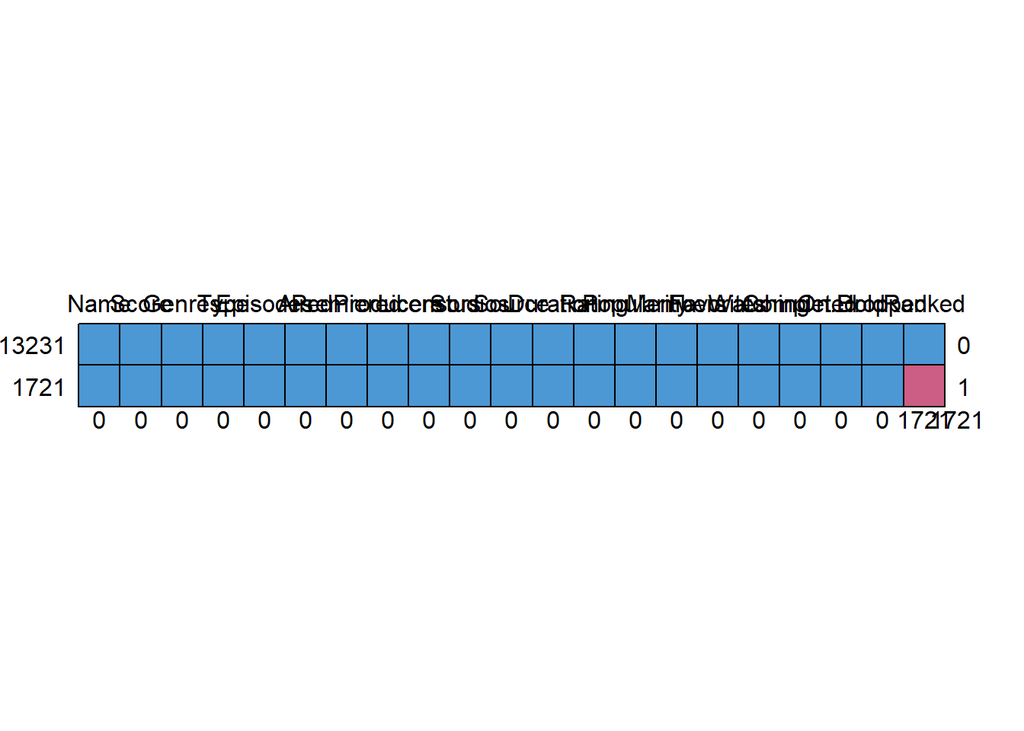

```
##       Name Score Genres Type Episodes Aired Premiered Producers Licensors
## 13231    1     1      1    1        1     1         1         1         1
## 1721     1     1      1    1        1     1         1         1         1
##          0     0      0    0        0     0         0         0         0
##       Studios Source Duration Rating Popularity Members Favorites Watching
## 13231       1      1        1      1          1       1         1        1
## 1721        1      1        1      1          1       1         1        1
##             0      0        0      0          0       0         0        0
##       Completed On.Hold Dropped Ranked
## 13231         1       1       1      1    0
## 1721          1       1       1      0    1
##               0       0       0   1721 1721
```

```r
md.pattern(dataset)
```

## Braki danych

Natomiast czyha jedno zagrożenie które odkryłem w późniejszym etapie analizy (jest to swego rodzaju wiadomość z przyszłości)

```r
dataset %>%
  filter(Name == "Unknown") %>%
  summarise(n())
```

```
##    n()
## 1 8554
```

Dlatego odsiewam nieznane tytuły - moim zdaniem każda licząca się produkcja, powinna mieć tytuł. W ten sposób znika nam blisko połowa rekordów.

```r
dataset <- dataset %>%
  filter(Name != "Unknown")
```

## Porządkowanie struktury datasetu

Przechodzę do konwersji arkusza do postaci, w której będę mógł nim swobodnie manipulować Mam kolumny, które wprost proszą się o konwersję na factor.

```r
table(dataset$Type)
```

```
##
##   Movie   Music     ONA     OVA Special      TV Unknown
##    1278     187     510    1128     530    2761       4
```

```r
dataset$Type <- as.factor(dataset$Type)
table(dataset$Source)
```

```
##
##  4-koma manga          Book     Card game Digital manga          Game
##           121            46            29             7           393
##   Light novel         Manga         Music         Novel      Original
##           460          1764            58           251          1659
##         Other  Picture book         Radio       Unknown  Visual novel
##           152            34             2           972           330
##     Web manga
##           120
```

```r
dataset$Source <- as.factor(dataset$Source)
table(dataset$Rating)
```

```
##
##                   G - All Ages      PG-13 - Teens 13 or older
##                           1304                           2863
##                  PG - Children R - 17+ (violence & profanity)
##                            514                            697
##               R+ - Mild Nudity                    Rx - Hentai
##                            496                            403
##                        Unknown
##                            121
```

```r
dataset$Rating <- as.factor(dataset$Rating)
```

Ale mam też takie, które choć bym chciał, nie jestem w stanie przekształcić w nieinwazyjny sposób. Kolumny takie jak:

```r
length(unique(dataset$Studios))
```

```
## [1] 659
```

```r
length(dataset$Studios)
```

```
## [1] 6398
```

```r
length(unique(dataset$Producers))
```

```
## [1] 2500
```

```r
length(dataset$Producers)
```

```
## [1] 6398
```

```r
length(unique(dataset$Licensors))
```

```
## [1] 211
```

```r
length(dataset$Licensors)
```

```
## [1] 6398
```

I szczególnie ta, w której pokładam najwięcej nadziei:

```r
head(dataset$Genres)
```

```
## [1] "Action, Adventure, Comedy, Drama, Sci-Fi, Space"
## [2] "Action, Drama, Mystery, Sci-Fi, Space"
## [3] "Action, Sci-Fi, Adventure, Comedy, Drama, Shounen"
## [4] "Action, Mystery, Police, Supernatural, Drama, Magic"
## [5] "Adventure, Fantasy, Shounen, Supernatural"
## [6] "Comedy, Drama, Josei, Romance, Slice of Life"
```

```r
length(unique(dataset$Genres))
```

```
## [1] 3011
```

Posiada one wiele rekordów rodzielonych przecinkami, więc zdecydowałem się na potrzeby badań, skorzystać z pakietu “stringr” który pomoże mi po prostu wykryć w ciągu znaków konkretny gatunek.

Jeszcze tylko kilka poprawek typu zmiennych:

```r
dataset$Episodes <- as.numeric(dataset$Episodes)
```

Kłopotliwa okazuje się również rubryka długości trwania odcinka, ponieważ zawiera dane w niewygodnym formacie

```r
str(dataset$Duration)
```

```
##  chr [1:6398] "24 min. per ep." "1 hr. 55 min." "24 min. per ep." ...
```

Stringr tutaj nie pomoże przez fakt że musimy znaleźć łańcuch, którego nie włączamy w zwracaną wartośĆ. Jedyny znany mi sposób żeby przekonwertować te dane na liczbowe (w moim założeniu na minuty), to wyrażenia regularne, które umożliwiają wyszukanie patternu, ale zwrócenie wartości, która leży przed nim. Na szczęście kolumna jest dość jednolita i polega tylko na tym, że to liczb dołączone są przypisy jednostek czasu. Wobec tego wyszukam sobie kolejno godzin, minut i sekund oraz przeliczę na minuty.

```r
convert_to_minutes <- function(x){
  hours <- as.numeric(str_extract(x, "\\d+(?=\\s*hr)")) %>% replace_na(0)
  minutes <- as.numeric(str_extract(x, "\\d+(?=\\s*min)")) %>% replace_na(0)
  seconds <- as.numeric(str_extract(x, "\\d+(?=\\s*sec)")) %>% replace_na(0)

  return((hours*60)+minutes+(seconds/60))
}

dataset$Duration <- convert_to_minutes(dataset$Duration)

str(dataset$Duration)
```

```
##  num [1:6398] 24 115 24 25 23 23 24 23 24 22 ...
```

Dodatkowo pipe i funkcja replace_na posłuży ustawieniu domyślnej wartości na 0 w razie uzyskania NA.

Finalny kształt datasetu:

```r
str(dataset)
```

```
## 'data.frame':    6398 obs. of  21 variables:
##  $ Name      : chr  "Cowboy Bebop" "Cowboy Bebop:The Movie" "Trigun" "Witch Hunter Robin" ...
##  $ Score     : num  8.78 8.39 8.24 7.27 6.98 8.06 8.76 7.91 8.52 7.9 ...
##  $ Genres    : chr  "Action, Adventure, Comedy, Drama, Sci-Fi, Space" "Action, Drama, Mystery, Sci-Fi, Space" "Action, Sci-Fi, Adventure, Comedy, Drama, Shounen" "Action, Mystery, Police, Supernatural, Drama, Magic" ...
##  $ Type      : Factor w/ 7 levels "Movie","Music",..: 6 1 6 6 6 6 6 6 6 6 ...
##  $ Episodes  : num  26 1 26 26 52 24 74 220 NA 178 ...
##  $ Aired     : chr  "Apr 3, 1998 to Apr 24, 1999" "Sep 1, 2001" "Apr 1, 1998 to Sep 30, 1998" "Jul 2, 2002 to Dec 24, 2002" ...
##  $ Premiered : chr  "Spring 1998" "Unknown" "Spring 1998" "Summer 2002" ...
##  $ Producers : chr  "Bandai Visual" "Sunrise, Bandai Visual" "Victor Entertainment" "TV Tokyo, Bandai Visual, Dentsu, Victor Entertainment" ...
##  $ Licensors : chr  "Funimation, Bandai Entertainment" "Sony Pictures Entertainment" "Funimation, Geneon Entertainment USA" "Funimation, Bandai Entertainment" ...
##  $ Studios   : chr  "Sunrise" "Bones" "Madhouse" "Sunrise" ...
##  $ Source    : Factor w/ 16 levels "4-koma manga",..: 10 10 7 10 7 7 7 7 7 7 ...
##  $ Duration  : num  24 115 24 25 23 23 24 23 24 22 ...
##  $ Rating    : Factor w/ 7 levels "G - All Ages",..: 4 4 2 2 3 2 5 2 2 2 ...
##  $ Ranked    : num  28 159 266 2481 3710 ...
##  $ Popularity: int  39 518 201 1467 4369 687 169 8 31 1039 ...
##  $ Members   : int  1251960 273145 558913 94683 13224 214499 614100 1830540 1352724 141832 ...
##  $ Favorites : int  61971 1174 12944 587 18 4101 29436 65586 126645 3124 ...
##  $ Watching  : int  105808 4143 29113 4300 642 11909 64648 137167 887333 11235 ...
##  $ Completed : int  718161 208333 343492 46165 7314 81145 214491 1462223 33 76881 ...
##  $ On.Hold   : int  71513 1935 25465 5121 766 11901 47488 61734 187919 12905 ...
##  $ Dropped   : int  26678 770 13925 5378 1108 11026 23008 99806 136245 12516 ...
```

## Analiza danych

### Score

Przechodzę do wstępnej analizy liczb, dostępnych w naszym datasecie.  
Na pierwszy ogień przeanalizuję końcową ocenę użytkowników, dzięki czemu dowiemy się, w jakim zakresie (0-10) wystawiane są najchętniej oceny

```r
min(dataset$Score)
```

```
## [1] 2.01
```

```r
max(dataset$Score)
```

```
## [1] 9.19
```

Dane wahają nam się od 2.01 do 9.19, więc biorąc pod uwagę skalę 10-cio stopniową, nie mamy pełnej rozpiętości danych. To wskazuje, że nie ma tytułów, które byłyby jednogłośnie okrzyknięte arcydziełem, ani też tragicznych produkcji. Mimo to, są ekstrema i na pewno coś kierowało odbiorcami, żeby tak ocenić dane anime.

```r
mean(dataset$Score)
```

```
## [1] 6.667427
```

```r
median(dataset$Score)
```

```
## [1] 6.6
```

Średnia i mediana znajdują się z drobnym błędem dokładnie w tym samym punkcie. Mamy tutaj idealną symetrię? Ciekawa sprawa, zobaczmy rozkład tej zmiennej.

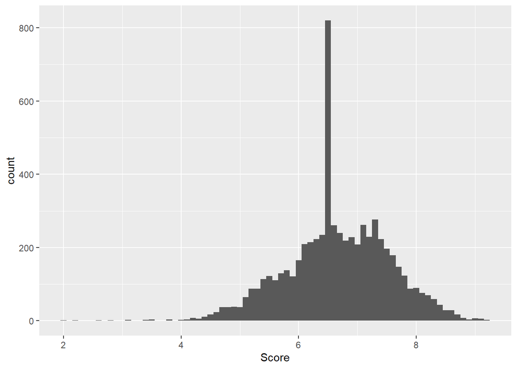

```r
ggplot(dataset, aes(x=Score))+
  geom_histogram(binwidth=.1)
```

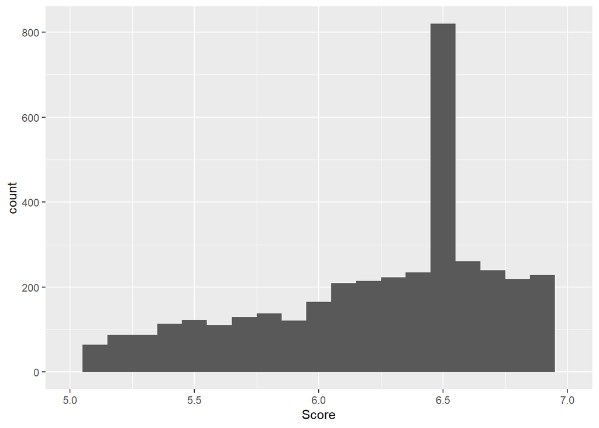

```r
ggplot(dataset, aes(x=Score))+
  geom_histogram(binwidth=.1)+
  xlim(5, 7)
```

I sprawa staje się jasna. Pierwszy rzut oka wskazuje nam dwie rzeczy - jest widoczny delikatny rozkład z centrum oscylującym wokół 6.7, natomiast jest też punkt 6.5 który zdaje się być gigantyczną odstającą daną. To tłumaczy skąd mediana i średnia mają taką wartość. Na tą potrzebę mogę spróbować ustawić skalę Y jako logarytmiczną

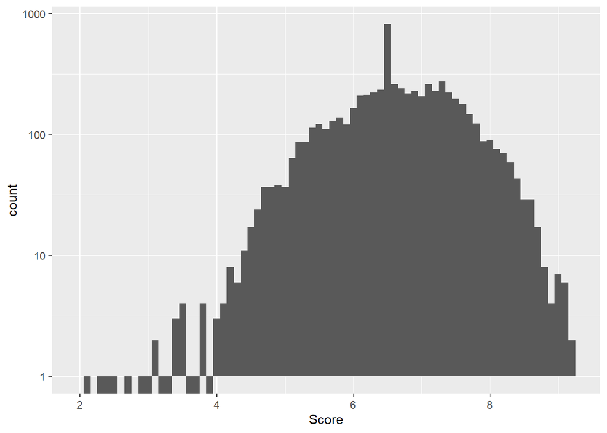

```r
ggplot(dataset, aes(x=Score))+
  geom_histogram(binwidth=.1)+
  scale_y_log10()
```

Teraz lepiej widac rozkład danych nieodstających. Warto byłoby sprawdzić, o co chodzi z tym punktem 6.5. Odfiltruję zakres od 6.4 do 6.6 aby być pewnym, że złapiemy wszystkie, które otaczają 6.5 i wyznaczę im wskaźniki pozycyjne.

```r
odstajace <- dataset %>%
  filter(Score >= 6.4 & Score <= 6.6)
summary(odstajace$Ranked)
```

```
##    Min. 1st Qu.  Median    Mean 3rd Qu.    Max.    NA's
##    5343    5871    6407    9574   13350   15730      97
```

```r
filtered <- dataset %>%
  filter(Score <= 6.5 | Score >= 6.52)

mean(filtered$Score)
```

```
## [1] 6.68324
```

```r
median(filtered$Score)
```

```
## [1] 6.71
```

```r
sd(filtered$Score)
```

```
## [1] 0.9171482
```

```r
var(filtered$Score)
```

```
## [1] 0.8411607
```

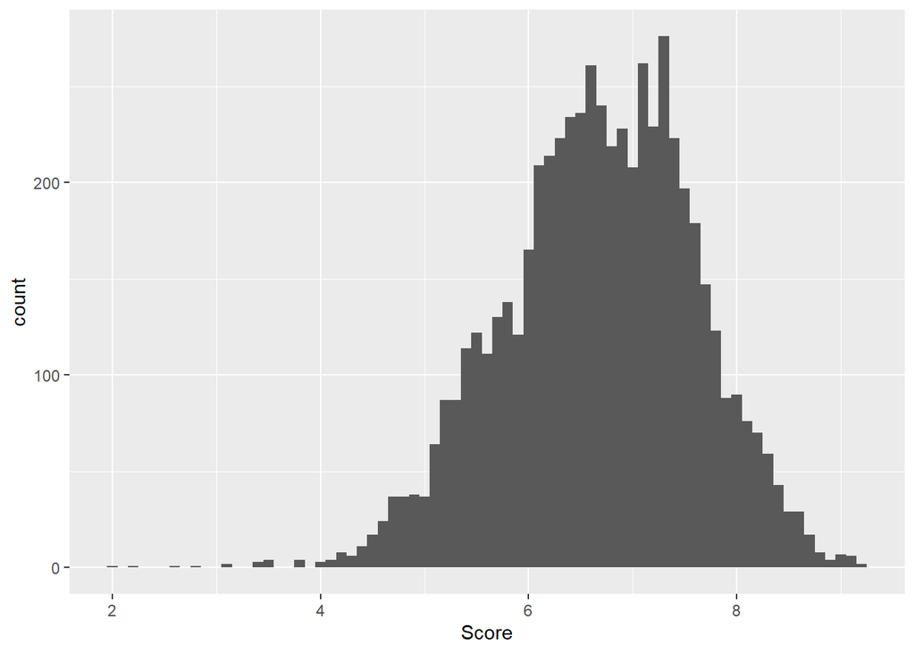

```r
ggplot(filtered, aes(x=Score))+
  geom_histogram(binwidth=.1)
```

Mediana wyszła dzięki temu wyższa. Jest wyższa od średniej co każde wnioskować, że skośność również jest lewostronna, ale minimalna. Rozkład ma teraz kształt, który można porównać do rozkładu normalnego. Jaka obserwacja się nasuwa? Użytkownicy chętnie oceniają produkcje ponad połowę skali, i są to głównie wartości w przedziale 5-9 punktów. Rozkład ma wybicie nieco ponad wynikiem 7 gwiazdek (ponieważ to jednostka stosowana w MAL’u), co może wskazywać, że ludzie mogą mieć tendencję do traktowania siódemki jako “złoty środek” - nie jest to tytuł wybitny, nie jest on średni, jest dobry, w sam raz pomiędzy 5 a 9, ponieważ 10 to już byłoby arcydzieło. Wariancja i odchylenie w granicy jedynki, mamy tutaj dane skupione wokół centrum o niskiej zmienności.

### Type

Zerknijmy na jedną z naszych zmiennych factorowych

```r
table(dataset$Type)
```

```
##
##   Movie   Music     ONA     OVA Special      TV Unknown
##    1278     187     510    1128     530    2761       4
```

```r
filtered %>%
  group_by(Type) %>%
  summarise(
    srednia = mean(Score),
    mediana = median(Score),
    maksimum = max(Score),
    minimum = min(Score),
    odchylenie = sd(Score)
    )
```

```
## # A tibble: 6 × 6
##   Type    srednia mediana maksimum minimum odchylenie
##   <fct>     <dbl>   <dbl>    <dbl>   <dbl>      <dbl>
## 1 Movie      6.56    6.68     9       2.63      1.08
## 2 Music      6.01    5.85     8.34    3.41      0.832
## 3 ONA        6.32    6.32     8.58    3.39      0.870
## 4 OVA        6.24    6.18     9.07    2.01      0.813
## 5 Special    6.65    6.65     8.57    3.47      0.728
## 6 TV         7.02    7.05     9.19    3.41      0.777
```

Przefiltrowanie po rodzaju emisji daje nam pierwszy rzut oka na preferencje użytkowników. Największe odchylenie ocen jest w przypadku filmów, potem blisko jednej całości jest przy “ONA” (Original Net Animation czyli emisja w internecie), najmniejsze wahanie widać w przypadku Special czyli dodatków do poszczególnych serii, na zasadzie spin-offów czy bonusu dla fanów. Pojawiają się pierwsze pytania w mojej głowie: Dlaczego to Movie jest najbardziej zróżnicowane względem oceny, a Special najmniej? Moja hipoteza jest taka, że widzowie kinowi podchodzą do produkcji bardziej emocjonalnie, być może ze względu na atmosferę panującą w sali kinowej, a może dlatego, że seansy w porównaniu do streamingu kosztują więcej, więc ludzie są bardziej krytyczni wobec nich. Special natomist to kategoria skierowana do fanów, wobec czego mogą być nią zainteresowane osoby, które obejrzały całą serię bazową, i chcą więcej. Dodatkowo, w przypadku Speciali, minimum również jest wyższe. Warto byłoby zerknąc dodatkowo na metrykę popularności, co doda tym danym głębię.

```r
filtered %>%
  group_by(Type) %>%
  summarise(
    minimum = min(Popularity),
    kwart1 = quantile(Popularity, 0.25),
    mediana = median(Popularity),
    kwart3 = quantile(Popularity, 0.75),
    maksimum = max(Popularity)
    )
```

```
## # A tibble: 6 × 6
##   Type    minimum kwart1 mediana kwart3 maksimum
##   <fct>     <int>  <dbl>   <dbl>  <dbl>    <int>
## 1 Movie        11  2556.   6676  10586.    14876
## 2 Music       539 10044.  12059  13553     14826
## 3 ONA         153  4742.   8164. 10810.    14516
## 4 OVA         143  4694.   7224   8964.    13360
## 5 Special     397  2989    5296   7950     14516
## 6 TV            1   815    2029   4746.    12953
```

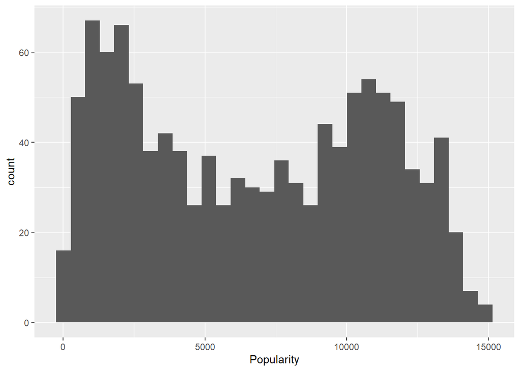

```r
films <- filtered %>%
  filter(Type == "Movie")
specials <- filtered %>%
  filter(Type == "Special")

ggplot(films, aes(x=Popularity))+
  geom_histogram()
```

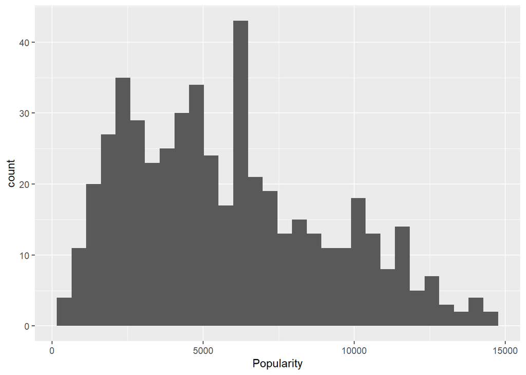

```r
ggplot(specials, aes(x=Popularity))+
  geom_histogram()
```

Wychodzi na to, że filmy są albo dobre, albo niedobre (moim zdaniem bardzo uniwersalna prawda), jednak histogram rzeczywiście pokazuje kształt wielbłąda o garbie blisko czołówki rankungu, a drugi za połową. Zobaczmy jeszcze na statystyki liczbowe mówiące o liczbie widzów

```r
filtered %>%
  filter(Type== "Movie") %>%
  summarise(
    suma_interakcji = sum(Watching, Completed, On.Hold, Dropped),
    srednia = mean(Completed),
    mediana = median(Completed)
  )
```

```
##   suma_interakcji  srednia mediana
## 1        40681913 34758.95  2680.5
```

```r
filtered %>%
  filter(Type== "Special") %>%
  summarise(
    suma_interakcji = sum(Watching, Completed, On.Hold, Dropped),
    srednia = mean(Completed),
    mediana = median(Completed)
  )
```

```
##   suma_interakcji  srednia mediana
## 1         9764699 18513.58    5076
```

Wygląda na to, że moje wcześniejsze stwierdzenie nie jest tak dalekie prawdzie. Rzeczywiście łączna liczba, oraz średnia interakcji jest wyższa, ale jednak mediana jest wyższa w przypadku Speciali. To pozwala wysnuć domysł, że społeczności zgromadzone wokół jednego tytułu dość wiernie mu towarzyszą, generując pod bonusowymi odcinkami bardziej przewidywalną oglądalność, niż w przypadku filmów, na które ludzie mogą iść pod wpływem tzw hype’u.

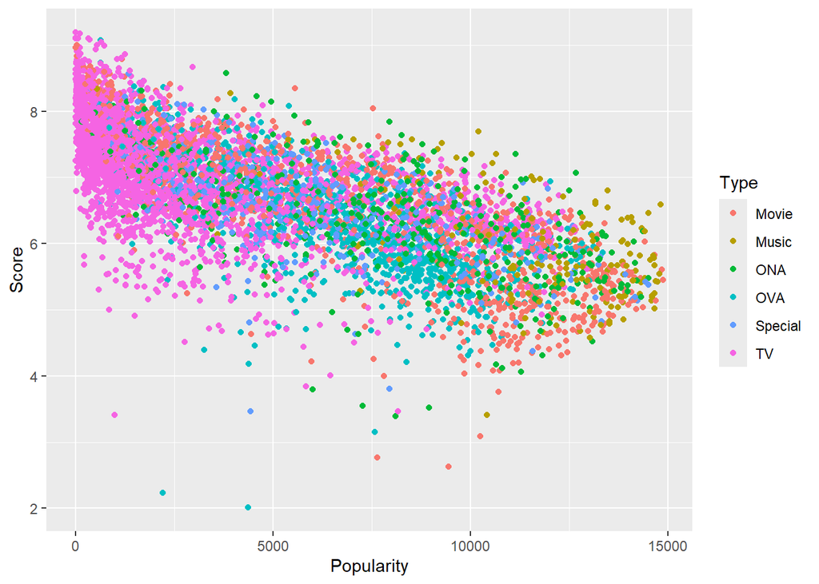

```r
ggplot(filtered, aes(x=Popularity, y=Score, color=Type))+
  geom_point()
```

W tym przypadku widać doskonale czarnego konia, którym jest kategoria “TV” mająca przewagę wśród najpopularniejszych serii, oraz również przodująca pod kątem wyniku punktowego. Gdy spojrzymy ponownie na tabelkę z medianą i średnią, rzeczywiście to TV przoduje. Również TV posiada rekord o najwyższym ustanowionym wyniku punktowym, warto się przyjrzeć, co to dokładnie za seria. Wezmę od razu 3 tytuły z najlepszą oceną:

```r
filtered %>%
  filter(Type=="TV") %>%
  arrange(desc(Score)) %>%
  slice_max(Score, n=3)
```

```
##                              Name Score
## 1 Fullmetal Alchemist:Brotherhood  9.19
## 2    Attack on Titan Final Season  9.17
## 3                     Steins;Gate  9.11
##                                                                Genres Type
## 1 Action, Military, Adventure, Comedy, Drama, Magic, Fantasy, Shounen   TV
## 2     Action, Military, Mystery, Super Power, Drama, Fantasy, Shounen   TV
## 3                                                    Thriller, Sci-Fi   TV
##   Episodes                       Aired   Premiered
## 1       64  Apr 5, 2009 to Jul 4, 2010 Spring 2009
## 2       16            Dec 7, 2020 to ? Winter 2021
## 3       24 Apr 6, 2011 to Sep 14, 2011 Spring 2011
##                                                                                                           Producers
## 1                                                Aniplex, Square Enix, Mainichi Broadcasting System, Studio Moriken
## 2 Production I.G, Dentsu, Mainichi Broadcasting System, Pony Canyon, Kodansha, Techno Sound, Pony Canyon Enterprise
## 3                                    Frontier Works, Media Factory, Movic, AT-X, Kadokawa Pictures Japan, Nitroplus
##                        Licensors   Studios       Source Duration
## 1 Funimation, Aniplex of America     Bones        Manga       24
## 2                     Funimation     MAPPA        Manga       23
## 3                     Funimation White Fox Visual novel       24
##                           Rating Ranked Popularity Members Favorites Watching
## 1 R - 17+ (violence & profanity)      1          3 2248456    183914   171871
## 2 R - 17+ (violence & profanity)      2        119  733260     44862   566239
## 3      PG-13 - Teens 13 or older      3          9 1771162    148452   114349
##   Completed On.Hold Dropped
## 1   1644938   75728   32456
## 2       553    6658    2090
## 3   1134756   60926   35600
```

Otrzymaliśmy czołówkę, uważaną za najlepsze tytuły wszechczasów (przez większość). Warto zauważyć, że dwa pierwsze tytuły bazują na tzw. “Mandze” czyli Japońskiej wersji komiksów. Trzecia natomiast bazowana jest na “Visual Novel” czyli książce przeplatanej sporadycznie grafikami. Spróbuję rozrysować podobny scatterplot jak wyżej

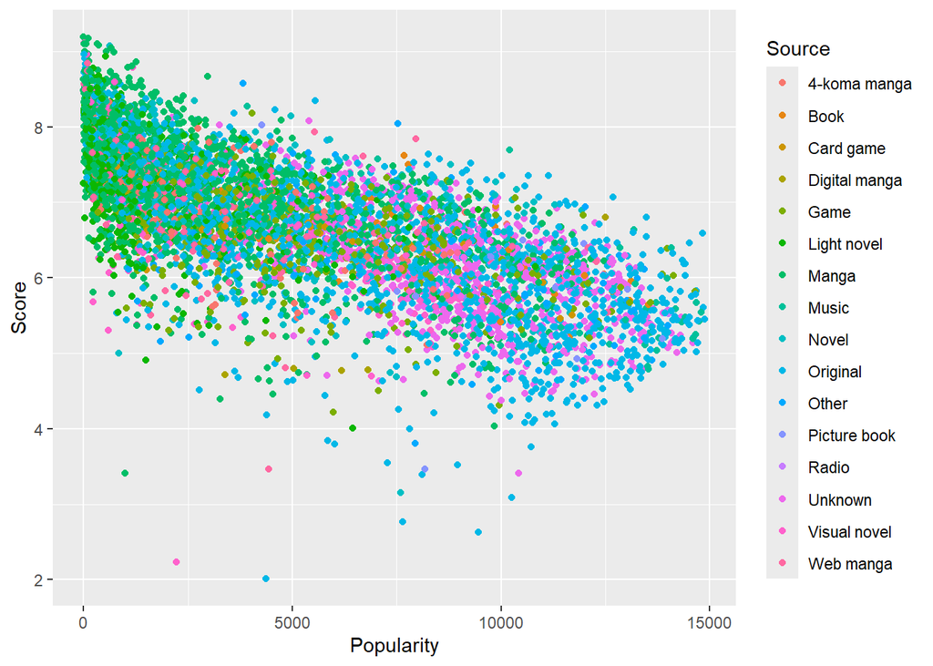

```r
ggplot(filtered, aes(x=Popularity, y=Score, color=Source))+
  geom_point()
```

```r
table(filtered$Source)
```

```
##
##  4-koma manga          Book     Card game Digital manga          Game
##           119            43            27             7           371
##   Light novel         Manga         Music         Novel      Original
##           443          1699            54           227          1477
##         Other  Picture book         Radio       Unknown  Visual novel
##           127            21             2           761           329
##     Web manga
##           107
```

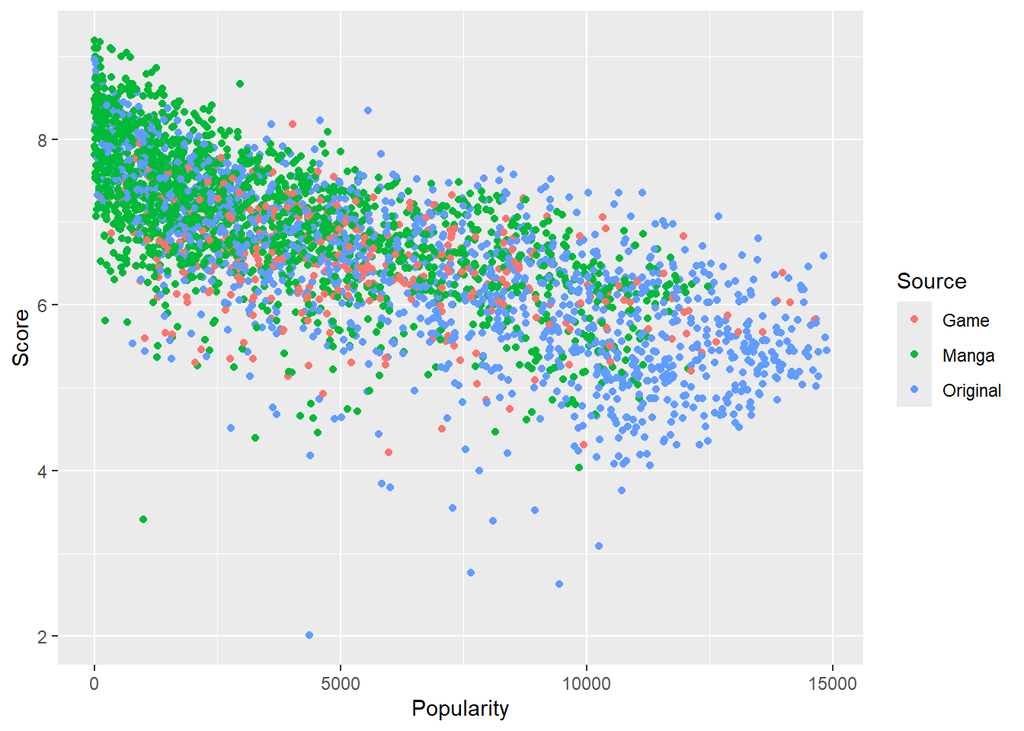

```r
clear_sources <-filtered %>%
  group_by(Source) %>%
  filter(Source=="Manga" | Source == "Original" | Source== "Game")
ggplot(clear_sources, aes(x=Popularity, y=Score, color=Source))+
  geom_point()
```

Teraz lepiej widać, że zdecydowana większość topowych Anime oparta jest na mandze. Być może wynika to z sentymentu widzów, którzy znają już historię, a teraz mają okazję doświadczyć ekranizacji ich ulubionych postaci? A może ekranizacje mang są po prostu doskonałe i nie ma znaczenia czy ktoś tą mangę zna czy nie, ona mimo wszystko trzyma pewien poziom? Jako osoba, która od pięciu lat interesuje się tym środowiskiem, osobiście mam wrażenie, że oba stwierdzenia mają pokrycie w empirii. Trzeci source czyli gry, to bardzo rozproszony zbiór punktów, który nie charakteryzuje się zwiększoną obecnością ani w czołówce, ani w peletonie. Oglądając tak te punkty, aż prosi się o zbadanie korelacji

```r
correlations <- filtered %>%
  group_by(Source) %>%
  summarise(
    korelacja = cor(Popularity, Score, method = "pearson")
  )
print(correlations)
```

```
## # A tibble: 16 × 2
##    Source        korelacja
##    <fct>             <dbl>
##  1 4-koma manga    -0.632
##  2 Book            -0.700
##  3 Card game       -0.760
##  4 Digital manga   -0.0343
##  5 Game            -0.469
##  6 Light novel     -0.469
##  7 Manga           -0.662
##  8 Music           -0.816
##  9 Novel           -0.552
## 10 Original        -0.720
## 11 Other           -0.569
## 12 Picture book    -0.479
## 13 Radio           -1
## 14 Unknown         -0.593
## 15 Visual novel    -0.683
## 16 Web manga       -0.489
```

Najjaśniejsza korelacja widnieje w przypadku radio i muzyki, jednak na poprzednim scatterplocie piosenki zajmowały zdecydowanie miejsce na końcowych lokatach. Później silna korelacja jest w przypadku książki, Mangi, Originalu i Visual Novelki a także 4-koma mangi, czyli takiej opowieści komiksowej, która nakierowana jest na skecz sytuacjyjny i wobec czego jest zamknięta w czterech właśnie panelach na stronie.

### Episodes

Kolejna kolumna, czyli liczba odcinków danej serii

```r
summary(filtered$Episodes)
```

```
##    Min. 1st Qu.  Median    Mean 3rd Qu.    Max.    NA's
##    1.00    1.00    6.00   13.75   13.00 1787.00      24
```

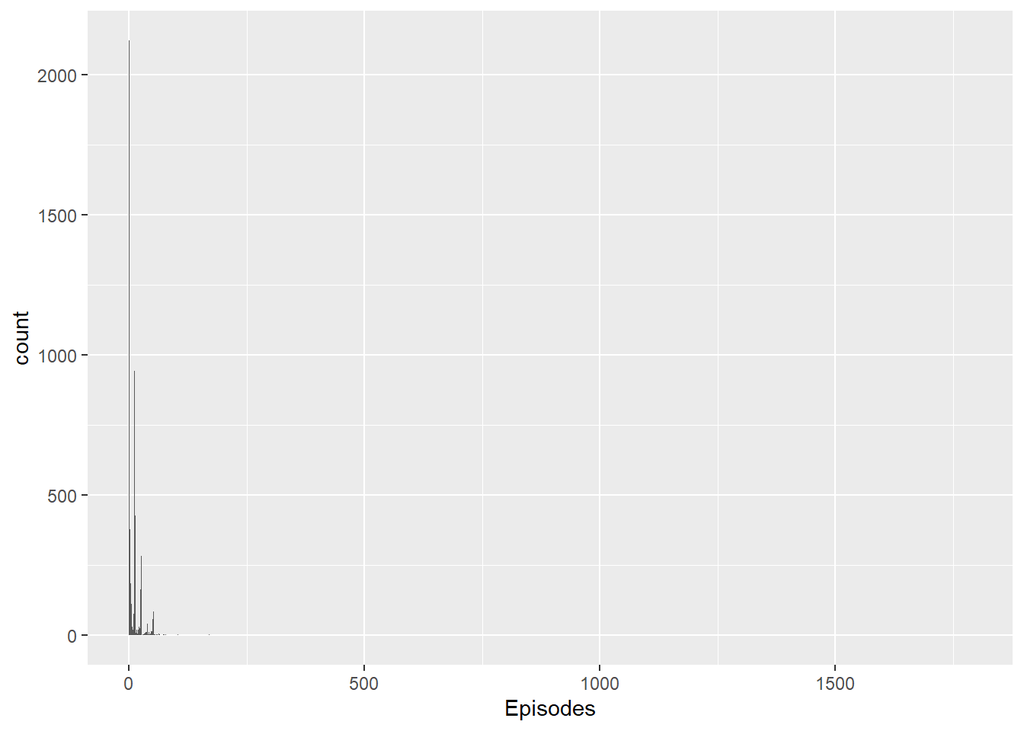

```r
filtered$Episodes <- as.numeric(filtered$Episodes)
ggplot(filtered, aes(x=Episodes))+
  geom_histogram(binwidth=1)
```

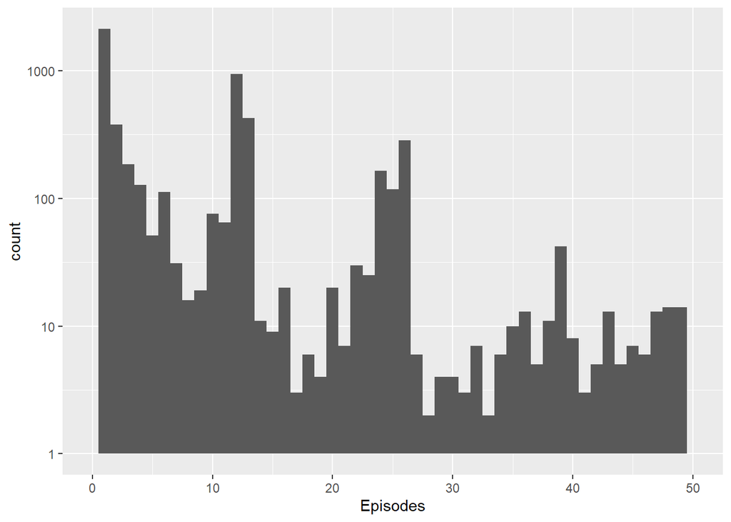

```r
filtered$Episodes <- as.numeric(filtered$Episodes)
ggplot(filtered, aes(x=Episodes))+
  xlim(0,50)+
  scale_y_log10()+
  geom_histogram(binwidth=1)
```

Widać rozkład który ma długi prawy ogon, jednak interesują mnie te charakterystyczne “dzidy” na początku. Czy te wartości są jakieś szczególne?

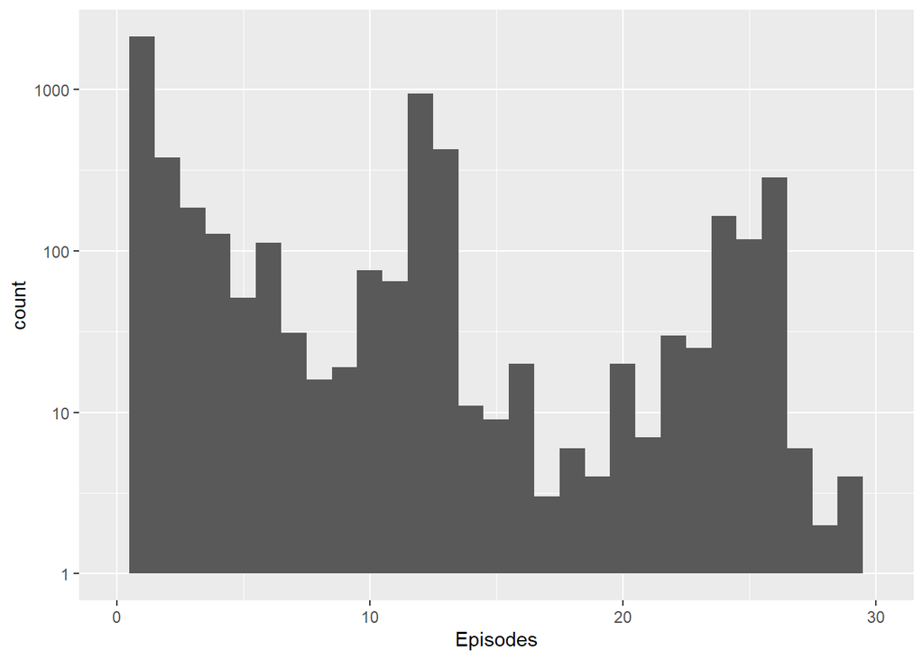

```r
filtered$Episodes <- as.numeric(filtered$Episodes)
ggplot(filtered, aes(x=Episodes))+
  xlim(0, 30)+
  scale_y_log10()+
  geom_histogram(binwidth=1)
```

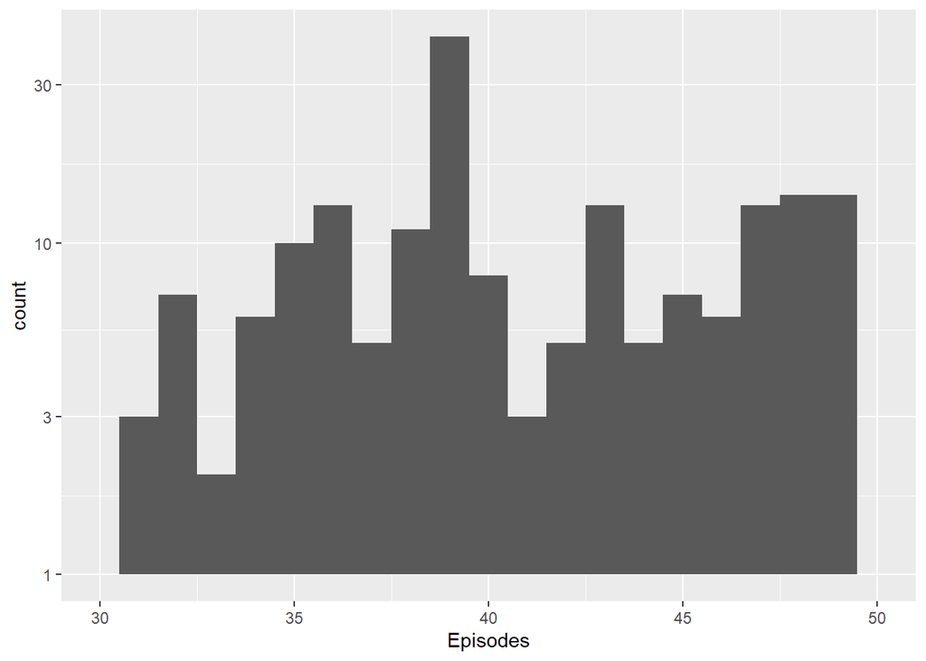

```r
ggplot(filtered, aes(x=Episodes))+
  xlim(30, 50)+
  scale_y_log10()+
  geom_histogram(binwidth=1)
```

39 i 48 to kolejne popularne długości serii. Czy długość sezonu ma jakiś wpływ na popularność albo ocenę anime?

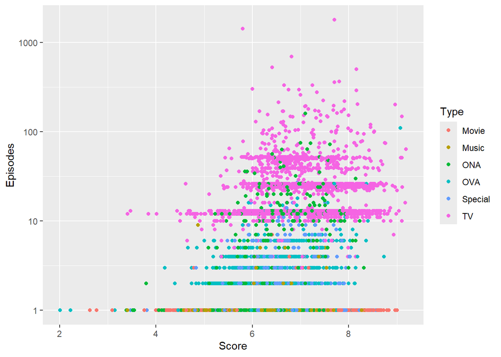

```r
ggplot(filtered, aes(x=Score, y=Episodes, color=Type))+
  scale_y_log10()+
  geom_point()
```

Tworzy nam się ciekawy pattern drabinki. Można z niej wywnioskować dwie rzeczy - Anime nadawane za pośrednictwem TV mają zasadniczo najwięcej odcinków, oraz znajdują się w czołówce wyniku, o czym mówiliśmy już wcześniej, natomiast może to też działać w drugą stronę - te produkcje, które spodobały się widowni, otrzymały kolejny i kolejny sezon, w wyniku czego odstające wartości w okolicach tysiąca to nie przypadek, a wieloletnie serie, które trwają tak długo jak “Klan” w porównaniu do innych polskich seriali:

```r
filtered %>%
  arrange(desc(Episodes)) %>%
  slice_max(Episodes, n=5)
```

```
##                    Name Score
## 1              Doraemon  7.70
## 2 The Affectuous Family  5.80
## 3     Ninja Hattori-kun  6.81
## 4       Superkid (1983)  6.41
## 5      Naruto:Shippuden  8.16
##                                                          Genres Type Episodes
## 1             Adventure, Comedy, Fantasy, Kids, Sci-Fi, Shounen   TV     1787
## 2                                                        Comedy   TV     1428
## 3                  Slice of Life, Comedy, Martial Arts, Shounen   TV      694
## 4                             Kids, Comedy, Super Power, School   TV      526
## 5 Action, Adventure, Comedy, Super Power, Martial Arts, Shounen   TV      500
##                          Aired   Premiered
## 1  Apr 2, 1979 to Mar 18, 2005 Spring 1979
## 2  Oct 1, 1976 to Mar 31, 1982   Fall 1976
```

[output cut: 21 more lines]

A jak ilość odcinków ma się do popularności?

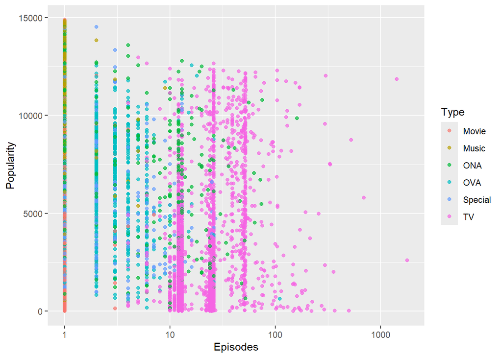

```r
ggplot(filtered, aes(x=Episodes, y=Popularity, color=Type))+
  geom_point(alpha=0.7)+
  scale_x_log10()
```

Z tego wykresu mogę tylko wyciągnąć wniosek, że to raczej ilość odcinków wynika w popularności, a nie popularność z ilości odcinków. Filmy przewijają się przez całe spektrum popularności, natomiast serie telewizyjne nie mają tendencji spadać na aż tak niskie lokaty. Widać też teraz lepiej, że serie TV zazwyczaj mają powyżej 10-ciu odcinków natomiast OVA kręcą się w okolicy 3-10 odcinków. Tak to wygląda prawdopodobnie ze względu na to, że OVA czyli kategoria podobna do “Special”, która zakłada jednak, że jest to dodatek jednak pełnowymiarowy do podstawowej opowieści, nie jest tak mocno ustrukturyzowana i ilość odcinków w takich “sezonach” waha się w granicach kilku. Może to wskazywać na to, że studia nie mają ciśnienia ze strony wydawców, na trzymanie się ramowych ilości odcinków uznanych za standard. Dzięki temu, te produkcje nie są tak rozwleczone, tylko dokładnie tyle, ile twórcy chcą przekazać, zamykają w dogodnej ilości odcinków.

### Rating wiekowy

Jako zmienna factorowa, będzie to dość proste

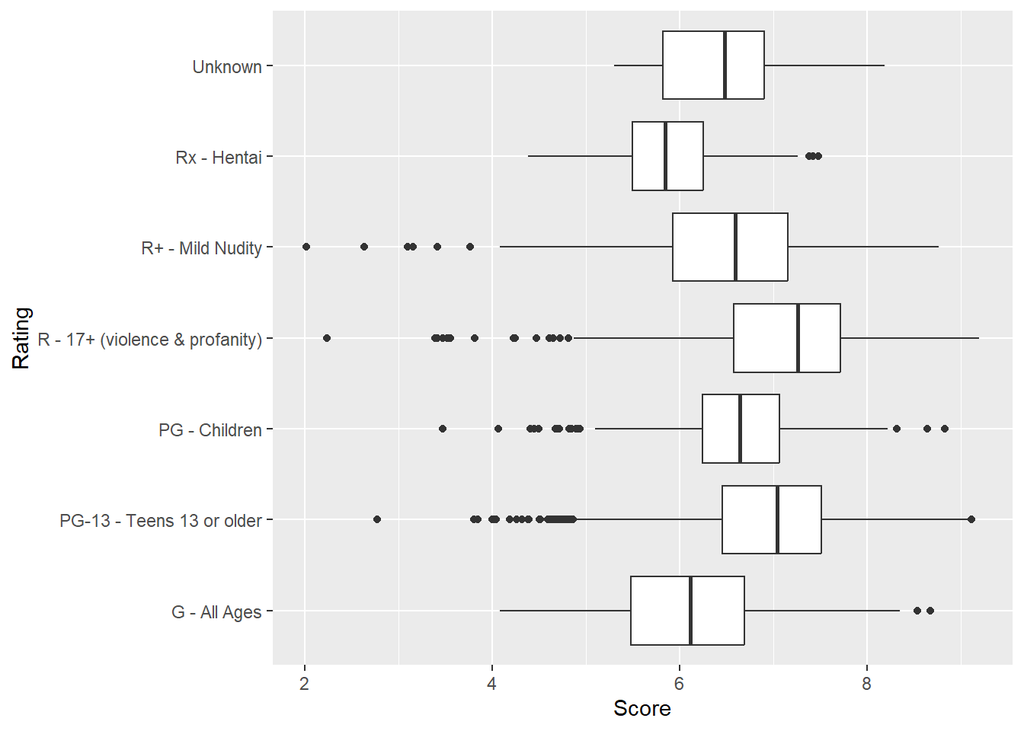

```r
rating <- filtered %>%
  group_by(Rating)

ggplot(rating, aes(x=Score, y=Rating))+
  geom_boxplot()
```

Wykres pięknie obrazuje pozycyjne statystki dla każdej z kategorii wiekowych. Mediana wyników punktowych jest najwyższa w przypadku grupy R - 17+, a największe rozproszenie występuje w przypadku R+ - Mild Nudity oraz G - All Ages/

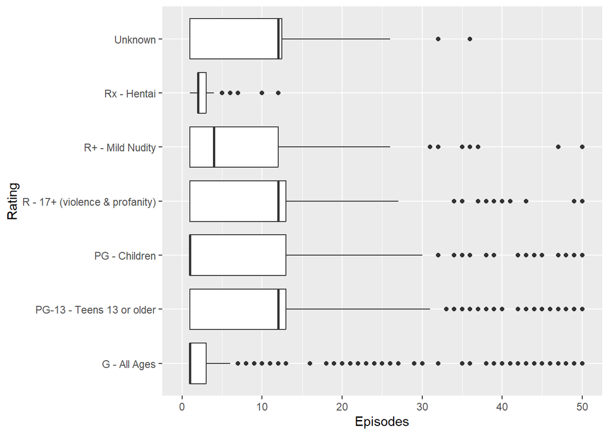

```r
ggplot(rating, aes(x=Episodes, y=Rating))+
  xlim(0,50)+
  geom_boxplot()
```

Pozwoliłem sobie dość brutalnie przyciąć wykres, ponieważ w przypadku logarytmowania osi X, obraz był trudny do interpretacji. To, co widać na grafice powyższej, to zarówno moja niekompetencja w pozostawieniu kategorii Unknown, jak również fakt, że treści kierowane wyłacznie do dorosłych w kategorii “Hentai”, to zazwyczaj serie między o zakresie 1-5 odcinków. Ze względów etycznych, nie będę kontynuować analizy tej kategorii. Kolejne kategorie to “Mild nudity” lub inaczej “ecchi” która traktuje ryzykowne treści jako dodatek do głównego wątku. Powiem tylko podobnie jak w przypadku poprzedniej, że skupiona jest na krótkich seriach. Podobna do niej, okrojona z drażliwych treści ale pozostawiająca przemoc jest R - 17+. Biorąc pod uwage nasze wcześniejsze obserwacje, można przypuścić, że będzie ona obecna szczególnie w produkcjach emitowanych w telewizji. Podobnie zachowuje się również PG-13 a więc kategoria dla nastolatków, natomiast grupy PG - Children i G - All Ages oscyluje wokół jedynki z długimi prawymi ogonami, co może wskazywać na to, że w tych kategoriach najczęściej pojawiają się filmy dla dzieci, lub pojedyncze odcinki. Warto dodać do tej analizy długość odcinka:

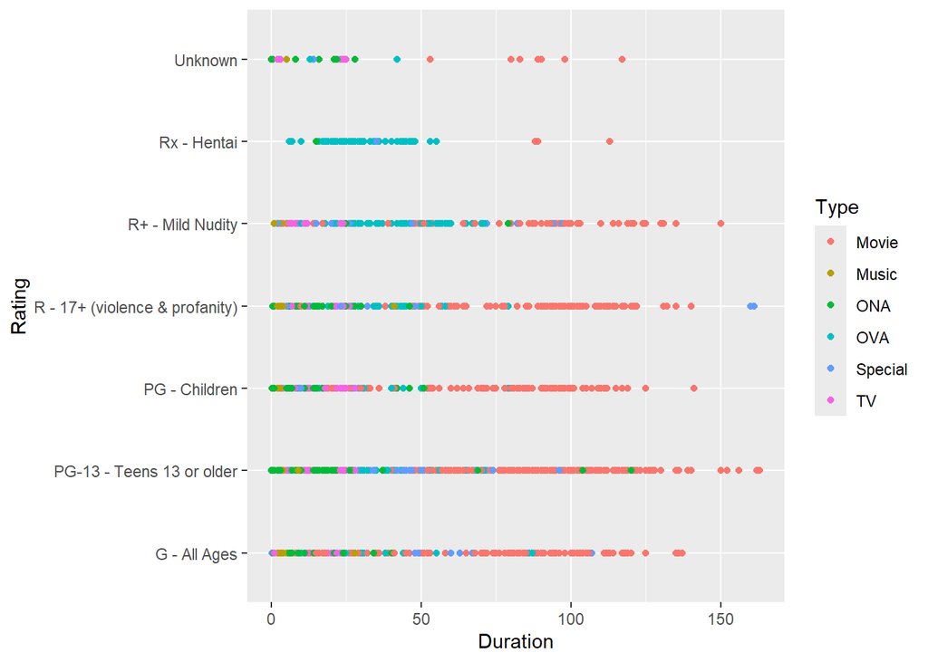

```r
ggplot(rating, aes(x=Duration,y=Rating,color=Type))+
  geom_point()
```

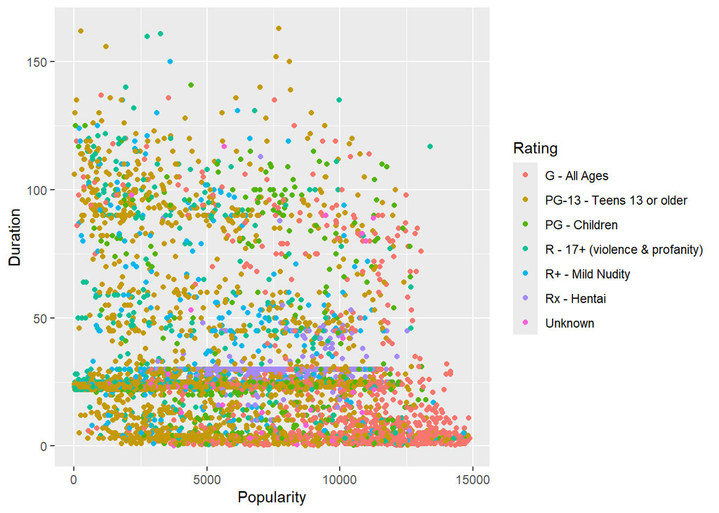

```r
ggplot(rating, aes(x=Popularity, y=Duration, color=Rating))+
  geom_point()
```

Ciężko wyznaczyć tutaj jakiś wiodący trend, widać jedynie, że produkcje krótkie, kategoryzowane dla wszystkich grup wiekowych, zazwyczaj trzymają się w ogonie rankingu, być może i zrozumiale - prawdopodobnie wynika to z tego, że dzieci nie wystawiają ocen na platformie, i w rankungu na czele pozostają aktywni użytkownicy którzy potrafią już posługiwać się komputerem.

### Producenci

Niestety na tą kategorię nie wystarczyło czasu, będzie ona uzupełniona po terminie oddania w formie osobistego uzupełnienia projektu.

### Gatunki

Najlepsze zostawiłem jednak na koniec. Z racji iż nie dysponuję factorem w tej kategorii, pozwolę zaczerpnąć z mojego doświadczenia i przeanalizować kilka kategorii, które moim zdaniem są najbardziej charakterystyczne: - Action - prawdopodobnie najpopularniejsza grupa, wszędzie gdzie dzieje się walka, akcja, rywalizacja - Romance - romanse, jedna z popularniejszych kategorii ze względu na grupę docelową wielu produkcji - Thriller - straszne filmy - Fantasy - fantastyka, ucieczka do innych światów, eskapizm - Sports - Supernatural - superbohaterowie posiadający supermoce - Comedy - skecze, gagi, sytuacyjne - Slice of Life - bardzo popularna grupa, opowiada o życiu codziennym, traktuje o innym tempie życia niż to, które dyktuje nam otoczenie

```r
action <- filtered %>%
   filter(str_detect(Genres, "Action"))
romance <- filtered %>%
   filter(str_detect(Genres, "Romance"))
thriller <- filtered %>%
   filter(str_detect(Genres, "Thriller"))
fantasy <- filtered %>%
   filter(str_detect(Genres, "Fantasy"))
sports <- filtered %>%
   filter(str_detect(Genres, "Sports"))
supernatural <- filtered %>%
   filter(str_detect(Genres, "Supernatural"))
comedy <- filtered %>%
   filter(str_detect(Genres, "Comedy"))
slice_of_life <- filtered %>%
   filter(str_detect(Genres, "Slice of Life"))

genres <- bind_rows(
  action %>% mutate(Gatunek = "Action"),
  romance %>% mutate(Gatunek = "Romance"),
  thriller %>% mutate(Gatunek = "Thriller"),
  fantasy %>% mutate(Gatunek = "Fantasy"),
  sports %>% mutate(Gatunek = "Sports"),
  supernatural %>% mutate(Gatunek = "Supernatural"),
  comedy %>% mutate(Gatunek = "Comedy"),
  slice_of_life %>% mutate(Gatunek = "Slice of Life")
)
genres$Gatunek <- as.factor(genres$Gatunek)

genres %>%
  group_by(Gatunek) %>%
  summarise(
    mean = mean(Score),
    med = median(Score),
    sd = sd(Score),
    min = min(Score),
    max = max(Score),
    n = n()
  ) %>%
  arrange(desc(n))
```

```
## # A tibble: 8 × 7
##   Gatunek        mean   med    sd   min   max     n
##   <fct>         <dbl> <dbl> <dbl> <dbl> <dbl> <int>
## 1 Comedy         6.88  6.94 0.838  2.01  9.19  2203
## 2 Action         6.89  6.95 0.836  3.15  9.19  1840
## 3 Fantasy        6.80  6.83 0.793  3.41  9.19  1362
## 4 Romance        7.04  7.1  0.728  4.26  8.96   979
## 5 Supernatural   7.07  7.17 0.843  3.52  8.96   803
## 6 Slice of Life  7.09  7.16 0.822  4.51  9      659
## 7 Sports         6.95  6.9  0.887  4.38  8.87   215
## 8 Thriller       7.31  7.55 1.11   3.52  9.11    83
```

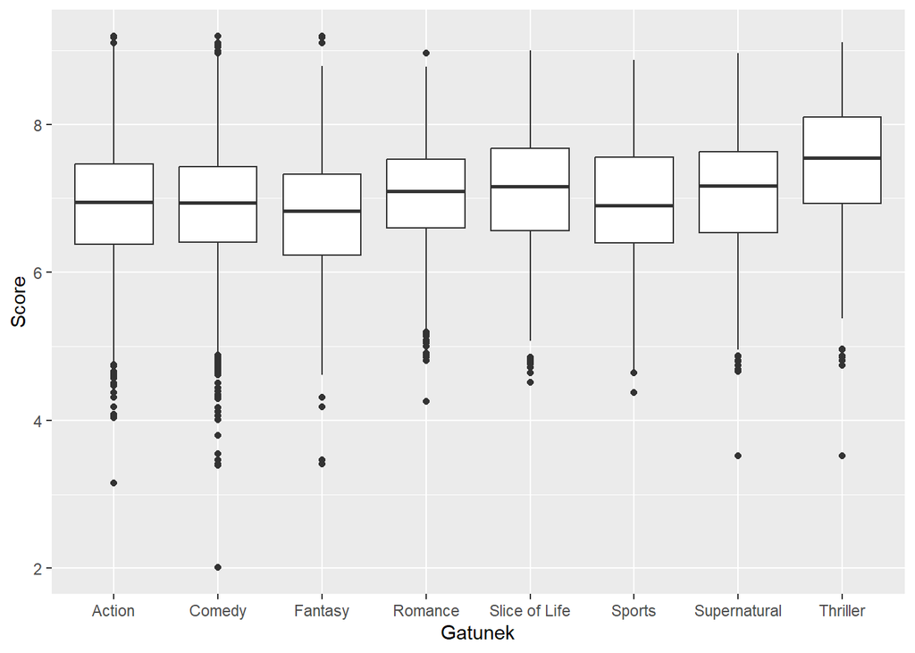

```r
ggplot(genres, aes(x=Gatunek, y=Score))+
  geom_boxplot()
```

Prosta tabelka a dostarczyła nam tak wiele. Posortowałem malejąco względem liczebności, dzięki czemu będę miał wstępny wgląd na siłę wskaźników. Najliczniejsza z poniższych grup to “Comedy” co może wskazywać, że fani Anime gustują w komedii, lub co bardziej prawdopodobne, większość anime ma mniejsze lub większe wstawki humorystyczne, co kategoryzuje je w tej grupie. Komedie z poniższego zestawienia mają prawie najmniejszą medianę, jednak to może być właśnie wynik wysokiej liczebności. Odchylenie całkiem wysokie, ale również zakres najszerszy - to komedie tworzą te najlepsze i najgorsze produkcje.  
Akcja i fantastyka mają zbliżone metryki, to w przypadku romansów zaczyna się dziać coś ciekaszego, ponieważ w ich przypadku odchylenie standardowe jest najmniejsze, czyli romansów może nie jest aż tyle co anime akcji, jednak ich widzowie są przyzwyczajeni do tego, jak te serie wyglądają, wobec czego ten gatunek skupia faktycznie zainteresowanych w przeciwieństwie do Akcji, która też ma większe odchylenie i większy zakres ocen. Być może to dlatego, że więcej ekranizacji filmowych to właśnie filmy akcji? Zobaczmy

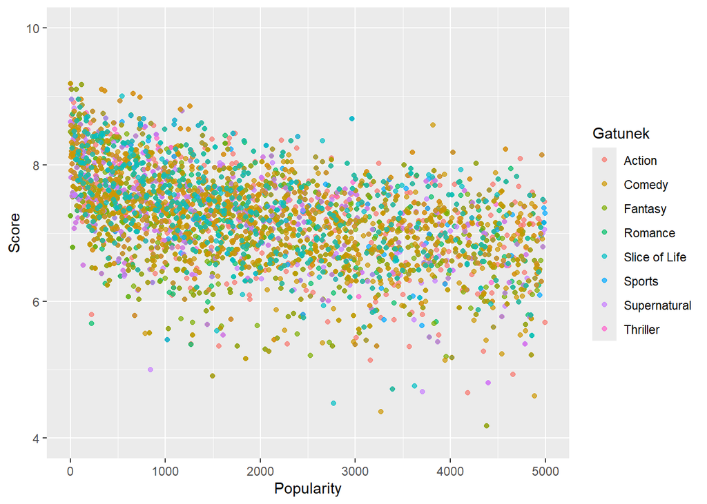

```r
ggplot(genres, aes(x=Popularity, y=Score, color=Gatunek))+
  xlim(0,5000)+
  ylim(4,10)+
  geom_point(alpha=0.7)
```

A jednak wykres wskazuje, że nie ma tu wielkiego skupienia tych wartości: anime każdego gatunku są rozproszone, co wskazuje na to, że społeczność fanów może być zróżnicowana i nie jest tak, że “topkę” okupuje jeden lub dwa gatunki.

## Podsumowanie

Dataset MyAnimeList dostarcza wiele wzorców na które warto zwrócić uwagę. Przede wszystkim dowiedzieliśmy się, że czołówkę popularnych Anime okupują produkcje emitowane w telewizji, bazowane na mangach, wypuszczane najczęściej w 12 lub 26 odcinkach, w których najczęściej przewijaja się komedie i sceny akcji.

Analiza gustów ludzkich nie należy do najprostszych, dlatego zdaję sobie sprawę, że jest to EDA, która powinna drążyć do samego końca każdy z aspektów. Przedstawiłem natomiast Państwu wszystko do tego stopnia, do którego nie bałem się eksperymentować z kodem i datasetem, aby nie zapędzić się w błędne wnioski i hipotezy.

Osobiście chciałbym tą analizą również zachęcić zainteresowanych do zagłębienia się w ten świat, ze względu na wartości, jakie niosą azjatyckie produkcje animowane. One różnią się podejściem od naszych, rodzimych seriali mentalnością. Slice of life dla osób, które potrzebują trochę zwolnić z natłokiem obowiązków, filmy dla tych, którzy szukają przypływu emocji, najlepiej w sali kinowej, czy też ci, którzy chcieliby co tydzień zasiadać do telenoweli, która będzie im stopniowo odkrywać kolejne warstwy historii. To wszystko jest na wyciągnięcie ręki, a witryna MyAnimeList.net jest doskonałym katalogiem wszystkich istniejących produkcji.